# ggnetwork

Vida Wang

# 简介

ggnetwork是根据ggplot2的语法,开发的用于网络图可视化的包.虽然igraph是优秀的network处理包，但是在可视化方面依然是弱势,为了加强网络可视化,在这里,我们结合igraph和ggnetwork填补igraph的空白. 在使用时,需要下载一下依赖包:

```r
install.packages(c("ggplot2", "igraph", "ggnetwork", "sna", "intergraph"))
```

# ggnetwork

整个包都围绕`ggnetwork`函数展开,为了能和igraph相结合,我们需要intergraph将igraph对象转换为可用的network对象,具体参数如下:

```r
ggnetwork(x, ...)
```

其中`x`是一个network对象或igraph对象. 例如,随意建立一个igraph网络，转换为ggnetwork对象:

1. 首先载入需要的包:

```r
library(ggplot2)
library(ggnetwork)
library(igraph)
library(sna)
library(intergraph)
```

2. 建立简单igraph网络

```r
edge_df <- data.frame(
  Source = c("A", "B", "C", "D", "F"),
  Target = c("B", "D", "A", "E", "B")
)
igraph_net <- graph_from_edgelist(as.matrix(edge_df), directed = F)
V(igraph_net)$weight <- 1:5#点的权重
node_count <- length(V(igraph_net))
V(igraph_net)$class <- sample(c("lncRNA","miRNA","gene"), node_count, replace = T)#点的权重
```

通过edge的信息,我们构建了一个igraph网络

```r
igraph_net
```

```
## IGRAPH UN-- 6 5 --
## + attr: name (v/c), weight (v/n), class (v/c)
## + edges (vertex names):
## [1] A--B B--D A--C D--E B--F
```

简单利用igraph内置的`plot`可视化

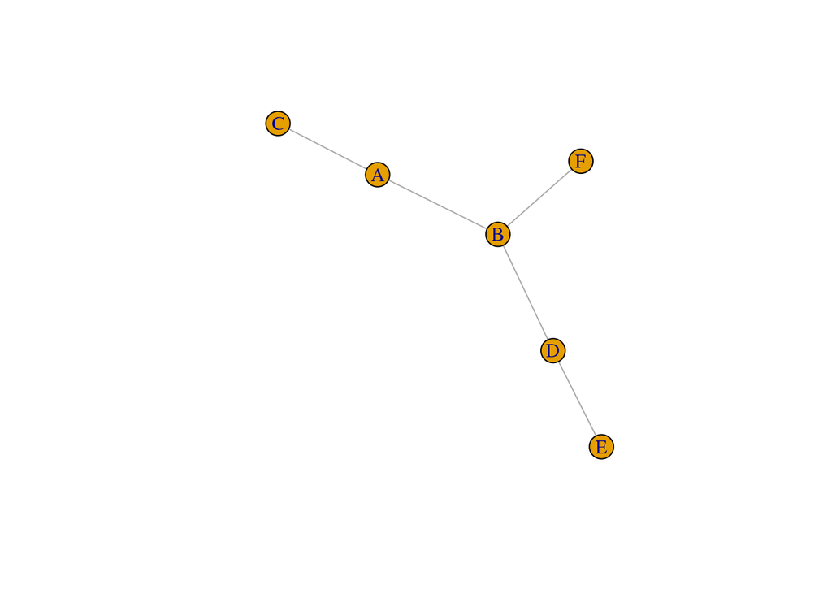

```r
plot(igraph_net)
```

3. 利用ggnetwork可视化

由于ggnetwork脱胎于ggplot2，所以`+`依然在ggnetwork中起了至关重要的作用.而`geom_edges`与`geom_nodes`则是整个包可视化network的核心. 利用`ggnetwork`得到ggnetwork对象:

```r
ggnetwork_net <- ggnetwork(x = igraph_net)
head(ggnetwork_net)
```

```
##            x         y  class  na.x vertex.names weight       xend
## 1 0.76175696 0.4648356 lncRNA FALSE            A      1 0.76175696
## 2 0.33427150 0.3553622   gene FALSE            B      2 0.33427150
## 3 0.03084336 0.6462895   gene FALSE            D      3 0.03084336
## 4 1.00000000 0.7479681   gene FALSE            C      4 1.00000000
## 5 0.00000000 1.0000000 lncRNA FALSE            E      5 0.00000000
## 6 0.22656508 0.0000000 lncRNA FALSE            F      1 0.22656508
##        yend na.y
## 1 0.4648356   NA
## 2 0.3553622   NA
## 3 0.6462895   NA
## 4 0.7479681   NA
## 5 1.0000000   NA
## 6 0.0000000   NA
```

从`ggnetwork_net`的返回值,我们可以清楚的了解到ggnetwork的工作原理，其实就是在二维平面上画点.

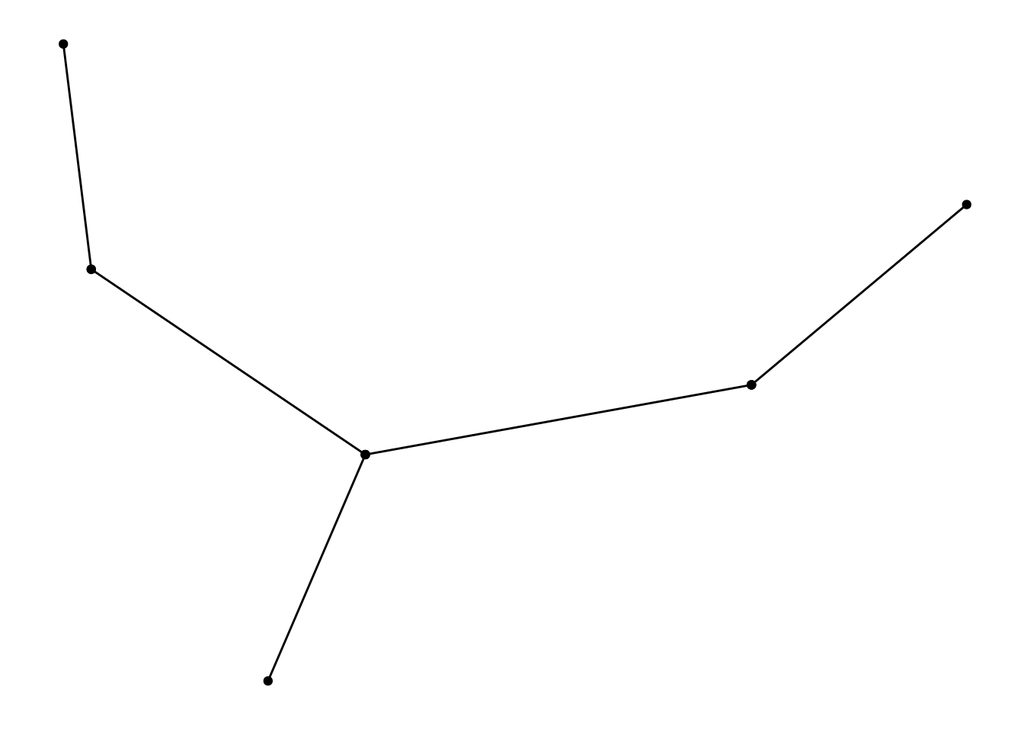

```r
ggplot(data = ggnetwork_net, aes(x = x, y = y, xend = xend, yend = yend)) +
  geom_edges() +
  geom_point() +
  theme_blank()
```

通过以上步骤,我们得到了一个最简单的可视化结果,接下来我们需要对图像进行一定程度的修饰.

# 针对边的修饰

经常我们需要对边的颜色进行改变,和ggplot2一样，我们只需要改变`colour`属性就行了.

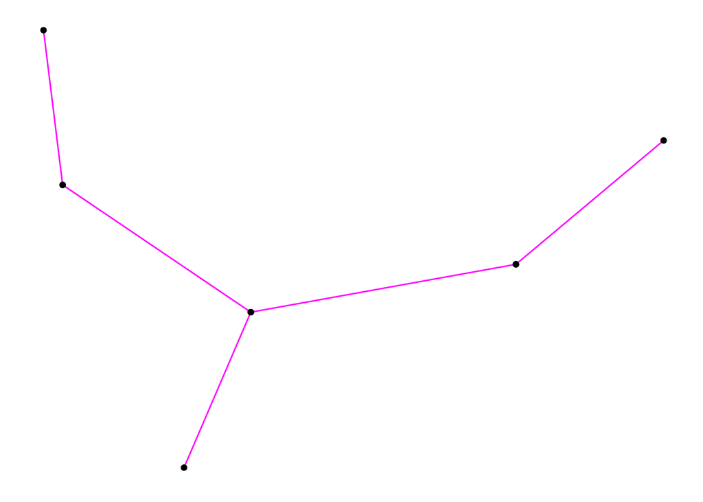

```r
ggplot(data = ggnetwork_net, aes(x = x, y = y, xend = xend, yend = yend)) +
  geom_edges(colour = "#FF00FF") +
  geom_point() +
  theme_blank()
```

同样,我们也可以修饰边的粗细和线型:

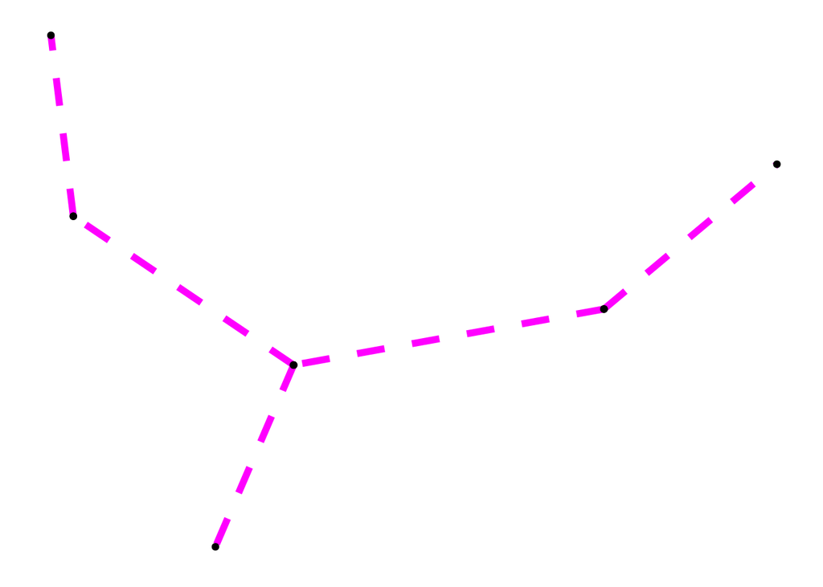

```r
ggplot(data = ggnetwork_net, aes(x = x, y = y, xend = xend, yend = yend)) +
  geom_edges(colour = "#FF00FF", size = 2, linetype = 2) +
  geom_point() +
  theme_blank()
```

# 针对点的修饰

和边类似,我们可以修饰点的大小和颜色.

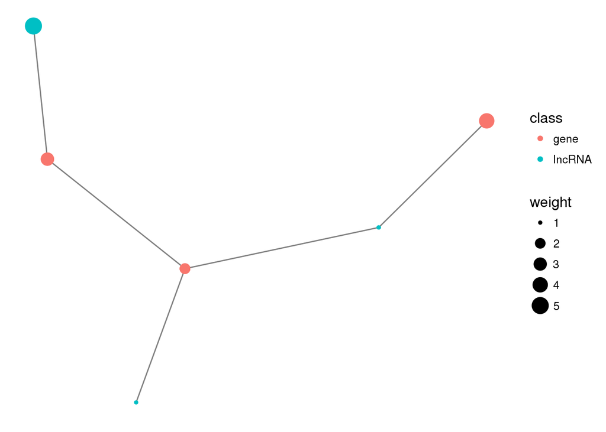

```r
ggplot(data = ggnetwork_net, aes(x = x, y = y, xend = xend, yend = yend)) +
  geom_edges(colour = "grey50") +
  geom_point(aes(colour = class, size = weight)) +
  theme_blank()
```

而和边不同,通常情况下,我们都需要在图中展示点的标签,此时,我们需要`geom_nodetext`来帮助我们做到这一点

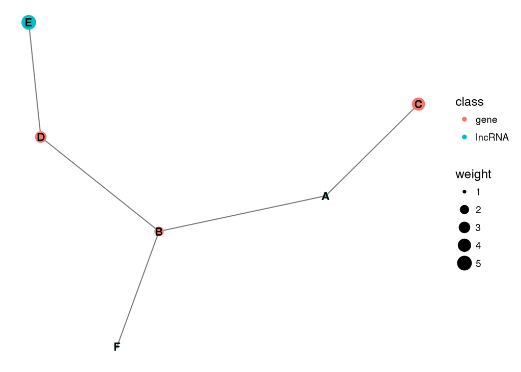

```r
ggplot(data = ggnetwork_net, aes(x = x, y = y, xend = xend, yend = yend)) +
  geom_edges(colour = "grey50") +
  geom_point(aes(colour = class, size = weight)) +
  geom_nodetext(aes(label = vertex.names),
                fontface = "bold")+
    theme_blank()
```

虽然把标签放在点中央还不错,但是通常情况下,我们用在生物学网络中时标签名会很长,这样就会显得很不合适,因此我们需要调整标签的位置. 而且有时候我们不需要把所有的标签都列出来.只需要把重要的node信息标注就行了.

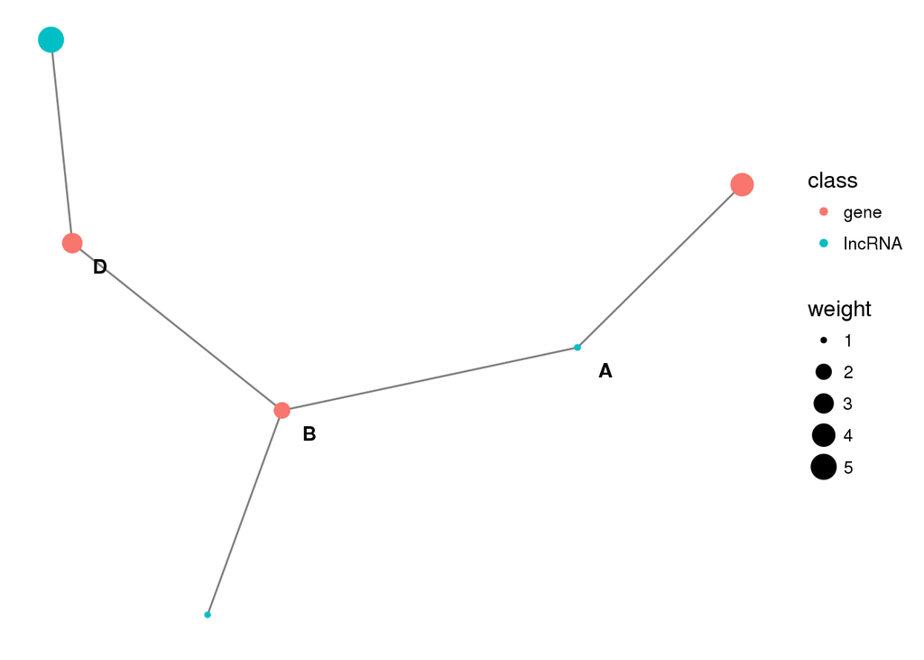

```r
ggplot(data = ggnetwork_net, aes(x = x, y = y, xend = xend, yend = yend)) +
  geom_edges(colour = "grey50") +
  geom_point(aes(colour = class, size = weight)) +
  geom_nodetext(data = ggnetwork_net[1:3,],aes(label = vertex.names),
                fontface = "bold",
                nudge_x = 0.04,
                nudge_y = -0.04)+
    theme_blank()
```

# layout

`sna`提供了许多不同的layout:

> circle | eigen | fruchtermanreingold | hall | kamadakawai | mds | princoord | random | spring | target |

更细致的描述可以上包中查询.

简单的示例:

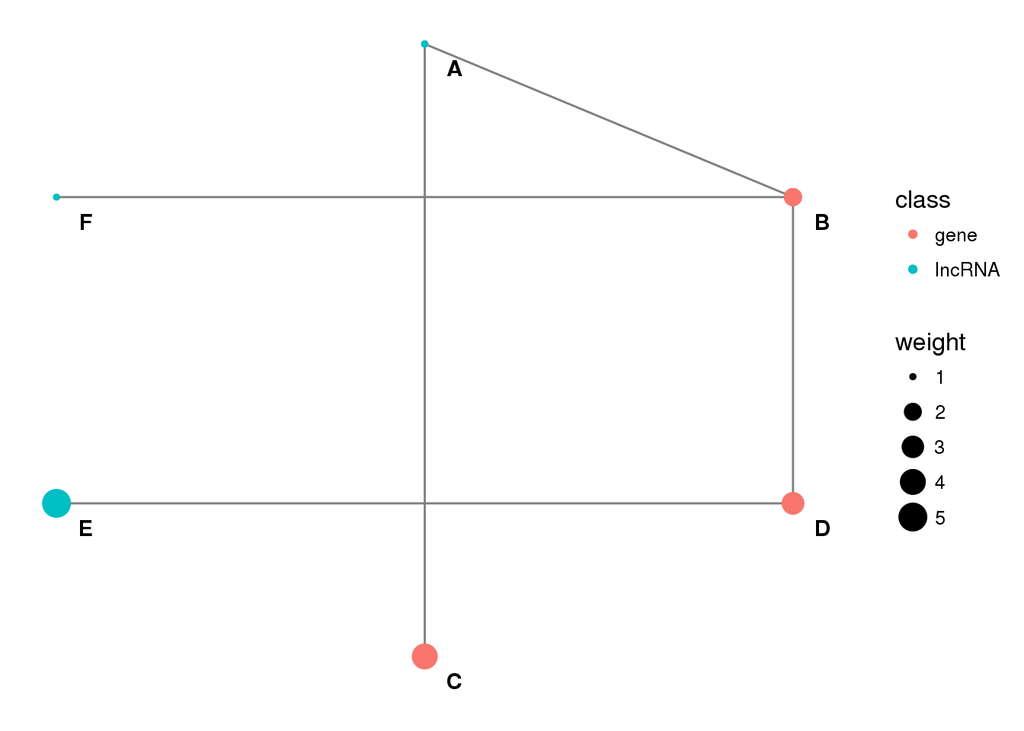

```r
new_ggnetwork_net <- ggnetwork(igraph_net, layout = "circle")
ggplot(data = new_ggnetwork_net, aes(x = x, y = y, xend = xend, yend = yend)) +
  geom_edges(colour = "grey50") +
  geom_point(aes(colour = class, size = weight)) +
  geom_nodetext(aes(label = vertex.names),
                fontface = "bold",
                nudge_x = 0.04,
                nudge_y = -0.04)+
    theme_blank()
```